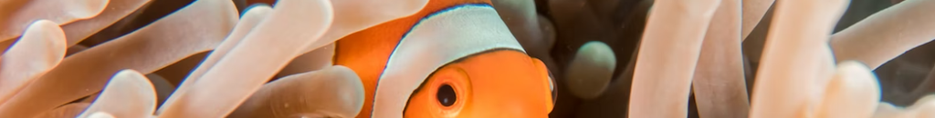

## Pre-processing Notebook

### Introduction to the dataset and experimental design

This Rmarkdown notebook describes the pre-processing and quality control of bulkRNAseq data of *Amphiprion ocellaris* larvae treated with a selection of drugs from 8dph to 13dph (5 days total), i.e. until control larvae had metamorphosed. The aim of the experiment was to detect the general effects of the organophosphate pesticide Chlorpyrifos (CPF) on clownfish larvae as they undergo metamorphosis, and specifically on their thyroid hormone signalling pathway. *n=10* larvae were collected at the end of each of the 5 treatments (i.e. at 13dph), RNA was extracted from each larva, and RNA was sequenced (total *n=50*). **Treatments**: DMSO (control), T3+IOP (positive control, induction of metamorphosis), MPI (negative control, blockade of metamorphosis), CPF (test drug), CPF+T3+IOP.

### FastQC reports and flagged issues

#### **Quality control of read data**

Raw (demultiplexed) fastq files were quality-checked based on reports generated by using FastQC v0.12.0 (RRID:SCR_014583; Andrews, 2010) with default parameters, before and after adapter trimming. Adapters were trimmed using the function bbduk (RRID:SCR_016969) of BBTools v39.01 (RRID:SCR_016968; Bushnell B., http://sourceforge.net/projects/bbmap/) with ktrim=r, k=23, and trimpolyg=40 given that the initial FastQC run had identified over-representation of polyG sequences.

| sample | pct.dup | pct.gc | tot.seq | seq.length |
| --- | --- | --- | --- | --- |
| trimmed_polyg_LTS23_FZ01_S1_L001_R1_001 | 57.73 | 49 | 11910539 | 12-151 |
| trimmed_polyg_LTS23_FZ01_S1_L001_R2_001 | 54.25 | 49 | 11910539 | 10-151 |
| trimmed_polyg_LTS23_FZ01_S1_L002_R1_001 | 55.37 | 49 | 10843799 | 11-151 |
| trimmed_polyg_LTS23_FZ01_S1_L002_R2_001 | 52.14 | 49 | 10843799 | 10-151 |
| trimmed_polyg_LTS23_FZ02_S2_L001_R1_001 | 60.51 | 49 | 13794102 | 10-151 |
| trimmed_polyg_LTS23_FZ02_S2_L001_R2_001 | 56.95 | 49 | 13794102 | 10-151 |
| trimmed_polyg_LTS23_FZ02_S2_L002_R1_001 | 58.47 | 49 | 12723079 | 15-151 |
| trimmed_polyg_LTS23_FZ02_S2_L002_R2_001 | 55.14 | 49 | 12723079 | 10-151 |
| trimmed_polyg_LTS23_FZ03_S3_L001_R1_001 | 58.22 | 48 | 12758489 | 10-151 |
| trimmed_polyg_LTS23_FZ03_S3_L001_R2_001 | 54.73 | 49 | 12758489 | 10-151 |

[output cut: 190 more lines]

**PASS modules**

FastQC modules that passed for all samples

| module | nb_fail | nb_pass | nb_warn |
| --- | --- | --- | --- |
| Adapter Content | 0 | 200 | 0 |
| Basic Statistics | 0 | 200 | 0 |
| Overrepresented sequences | 0 | 200 | 0 |
| Per base N content | 0 | 200 | 0 |
| Per base sequence quality | 0 | 200 | 0 |
| Per sequence quality scores | 0 | 200 | 0 |

**WARNING/FAIL metrics**

FastQC modules with FAIL or WARN flags

| module | nb_fail | nb_pass | nb_warn |
| --- | --- | --- | --- |
| Per base sequence content | 100 | 0 | 100 |
| Per sequence GC content | 45 | 0 | 155 |
| Per tile sequence quality | 150 | 0 | 50 |
| Sequence Duplication Levels | 174 | 0 | 26 |
| Sequence Length Distribution | 0 | 0 | 200 |

### Failed: per-base sequence content

🚫 **Failed: per-base sequence content**  
This module issues a warning if the difference between A and T, or G and C is greater than 10% in any position; and a fail if this difference is greater than 20%.  
As indicated by the [FastQC documentation](https://www.bioinformatics.babraham.ac.uk/projects/fastqc/Help/3%20Analysis%20Modules/4%20Per%20Base%20Sequence%20Content.html), *“Any library which is generated based on the ligation of random hexamers or through tagmentation should theoretically have good diversity through the sequence, but experience has shown that these libraries always have a selection bias in around the first 12bp of each run. This is due to a biased selection of random primers, but doesn’t represent any individually biased sequences. **Nearly all RNA-Seq libraries will fail this module because of this bias**, but this is not a problem which can be fixed by processing, and it doesn’t seem to adversely affect the ablity to measure expression.”*

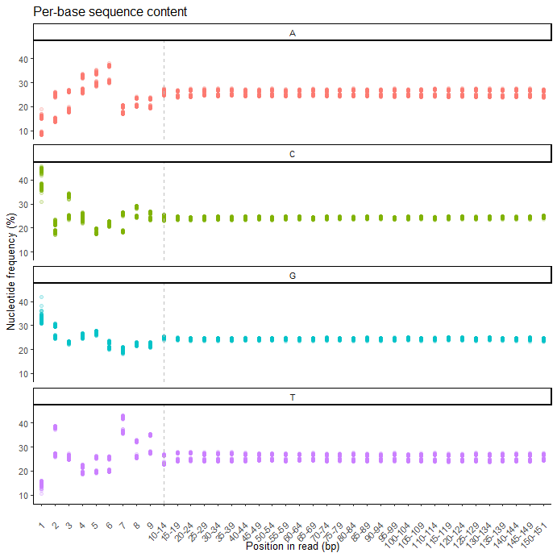

### Failed: Per sequence GC content

🚫 **Failed: Per sequence GC content**  
This module issues a warning if the sum of the deviations from the normal distribution represents more than 15% of the reads; and a fail if this sum represents more than 30% of the reads.  
**Below, the GC content distribution of all reads obtained in the dataset (colored by sample) and, under it, the theoretical GC-content distribution obtained from a simulated run of 25million 150bp reads on the clownfish transcriptome**

As can be seen, the obtained distribution, with a peak around 53% is very similar to the simulated expected distribution. It is therefore likely that the warning from FastQC comes from the programme not having the clownfish reference as a term of comparison (and this reference not being normally distributed).

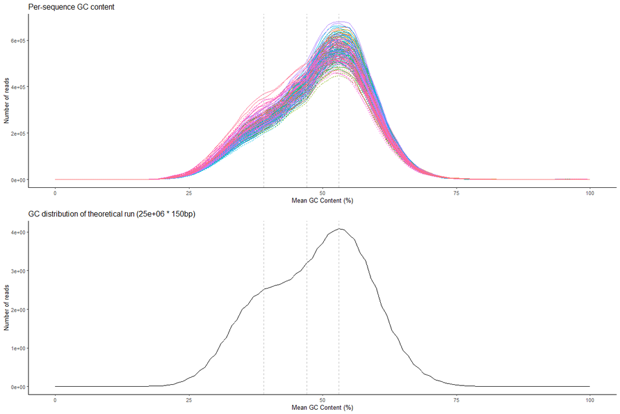

### Failed: per-tile sequence quality

🚫 **Failed: per-tile sequence quality**  
This module will issue a warning if any tile shows a mean Phred score more than 2 less than the mean for that base across all tiles; and a fail if this is less than 5 than the mean for that base across all tiles.  
**Below, average tile quality score across the entire chip, for all samples, and then separated by sequencing lane and side of the chip**

As can be seen, this sequencing run suffered from two main problems. In red: one tiles that produced no data throughout the whole run, for both read directions. This was followed up with the sequencing facility and linked to a common manufacturing defect for patterned flowcells. Areas of loss of quality, especially for advanced positions of some R2 reads, were also detected. Since overall yield and quality of the run were well within Illumina’s specification ( >1000M PF fragments and Q30 bases >75%), the issue was considered non prejudicial.

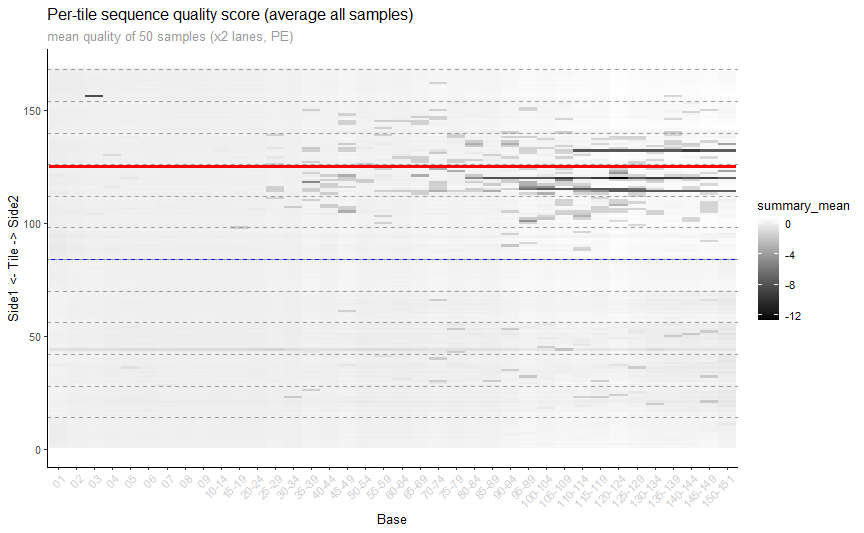

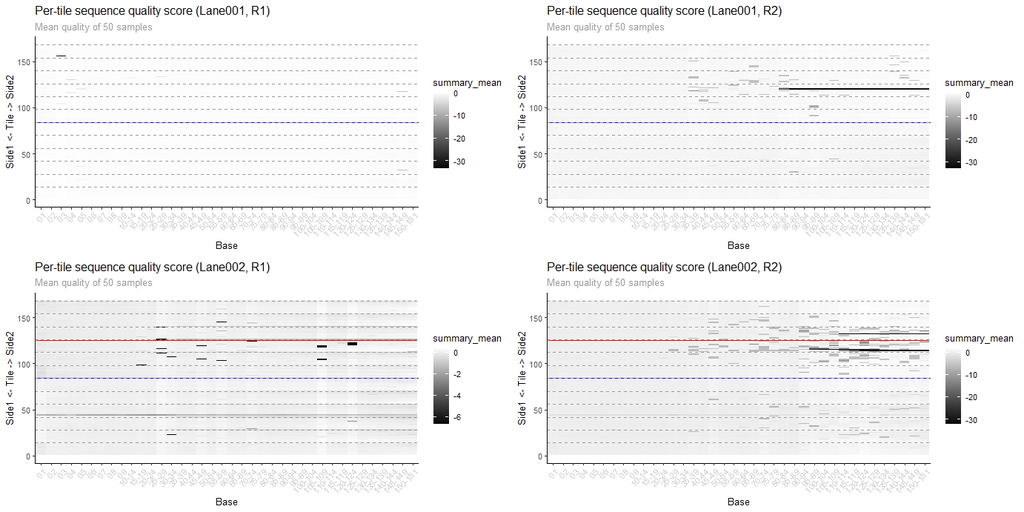

### Failed: sequence duplication levels

Based on dupRadar documentation, identifying a trend whereby duplication rates actually increase as a function of expression levels would be expected. Based on the plots below however, there appears to be an underlying low-sequencing-depth problem of the dataset, whereas most genes are represented by very few reads. Accordingly, and though the expecte trend is seen, there are also appear to be “step-wise” high duplication rate levels for lowly-detected genes, which may be indicative of PCR amplification artefacts. This hsould be followed up with the sequencing facility in adjusting the coverage for future runs.

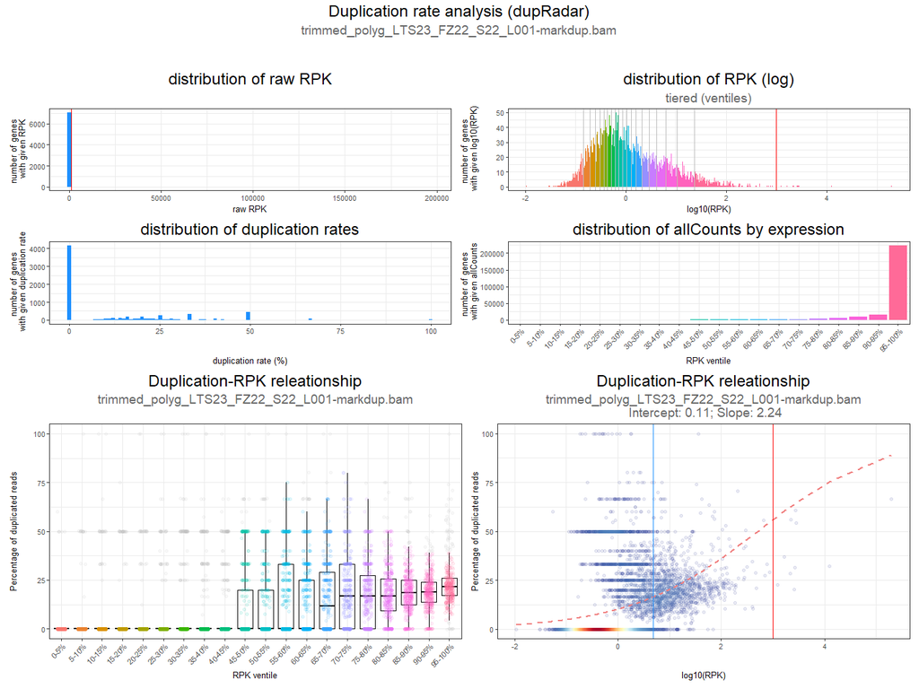

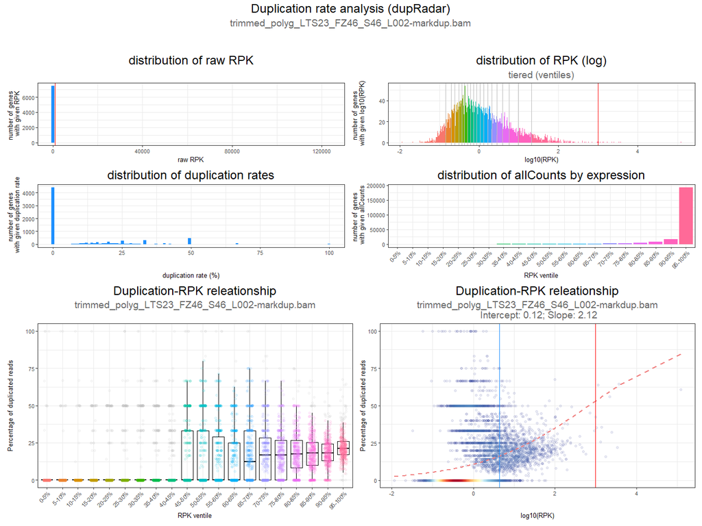

### Warning: sequence length distribution

🚫 **Warning: sequence length distribution**  
This module raises a warning if all sequences are not the same length.

Note that this is expected given that FastQC was run on reads that underwent trimming beforehand.

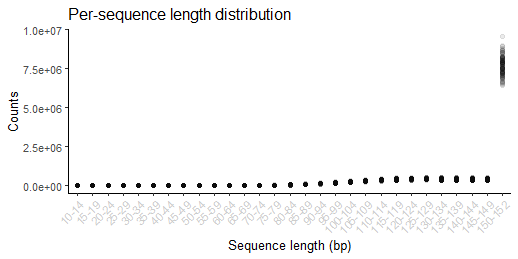

### Sample contamination (FastQScreen)

**Sample contamination (FastQScreen)**

As a further quality control step to detect sample contamination, trimmed reads were also run through FastQ Screen v0.15.2 (RRID:SCR_000141; Wingett, Andrews, 2018) with default parameters, against a manually curated set of genomes including — in addition to default ones — those of other fish species used by neighbouring laboratories (goldfish Carassius auratus: ASM336829v1, carp Cyprinus carpio: ASM1834038v1, zebrafish Danio rerio: GRCz11), the three main live foods fed to our fish (Artemia franciscana: AFR02, Brachionus rotundiformis: ASM1680229v1, Chlorella vulgaris: cvul), and additional possible contaminating species (ant Formica exsecta: ASM365146v1). All FastQ Screen genomes were indexed with bowtie2 as per FastQ Screen recommendation.

**Below — and for each treatment — an overview of the percentage of reads belonging to each species, in each of the samples.**

As can be seen for most samples there is mimimal sample contamination (non-clownfish reads), and contaminating reads (usually less than 2% of all reads) can be accounted for and belong to the *Artemia franciscana* nauplii we feed the larvae with (red). While we do note that one specific larva in the CPF+T3IOP condition has relatively high percentage of non-clownfish (artemia) reads (10%), overall we consider our dataset to not require further intervention.

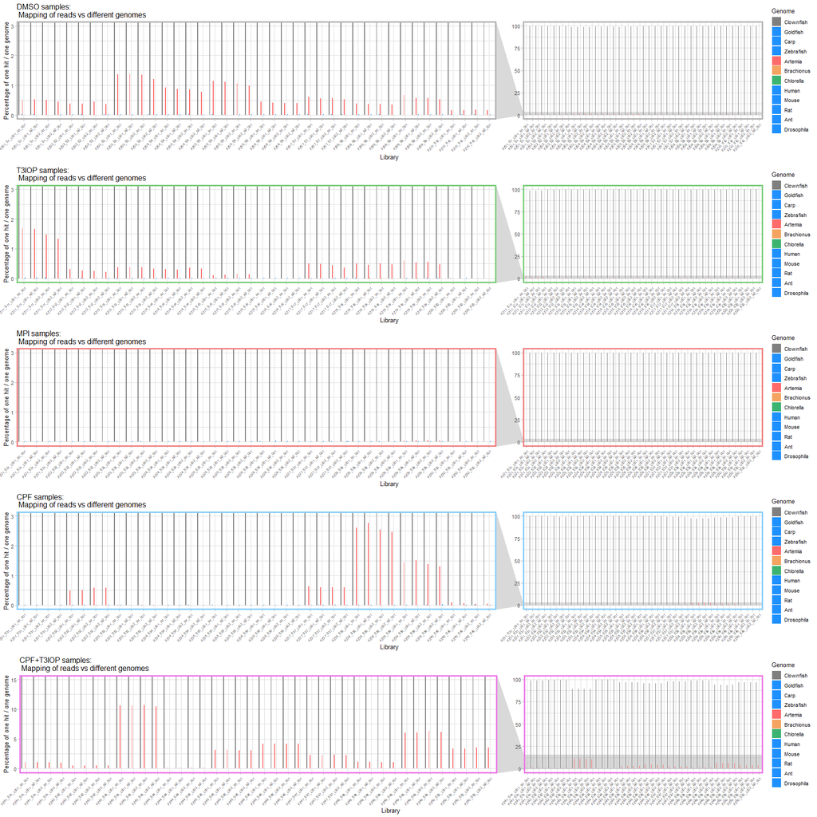

### Packages used

**Analysis Notebook**  
*Reynaud, Vianello, et al. “The multi-level effect of chlorpyrifos during clownfish metamorphosis”*  
*RNotebook by Stefano Vianello, Marine Eco-Evo-Devo unit, Academia Sinica Marine Research Station*  
This work is licensed under a [Creative Commons Attribution-NonCommercial 4.0 International License](http://creativecommons.org/licenses/by-nc/4.0/) with the additional reservation of the rights to non-human text and data mining, AI training, and similar technologies, which are not granted.